# Java Development Kit (JDK)

JDK represents a toolset for developing Java applications. Consists of Java compiler(javac), Java Virtual Machine(JVM), standard libraries, documentation and other tools.

### JDK Structure

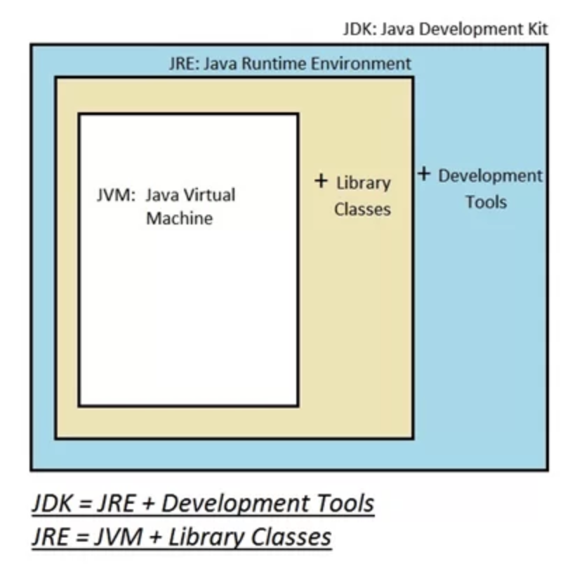

### Javac

Java compiler compiles *.java text files into* .class files that contains byte code for further running on JVM. This files can be run on any machine on any platform that has the JVM installed.

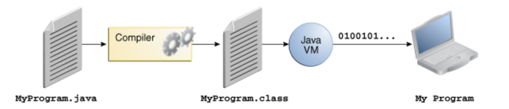

## Simplest Java Program

Java application, even the simplest one, contains the following lines of code:

```java
public class Demo {
    public static void main(String[] args) {
        System.out.println("Hello World");
    }
}
```

**Every** java file contains a class definition `class ClassName {}` Class is like a blueprint for some entity. If class declared as public - name of .java file should match the name of the this class. Java program should have an entry point of a program - **main** method. It should be **public and static**.  
*public* - keywords used to define a member available for everyone outside the class definition.  
*static* - keyword used to define a variable as a class variable. Classes maintain one copy of class variables regardless of how many instances exist of that class. "static" can also be used to define a method as a class method. Class methods are invoked by the class instead of a specific instance, and can only operate on class variables.  
**void** keyword used to define a return type of a function. It means that function doesn't return anything.  
**String[] args** - array of command line arguments of the type String.  
**System** - java standard library's class name  
**out** - static field, represents a standard output stream(in out case - the console).  
**println** - static method, that user standard output stream and print messages.